# Vector spatial features: Points, lines, and polygons in R

```r
GROUP_1 = subset(DEPARTMENTS_1, DPTO_NAREA >= mean(DEPARTMENTS_1$DPTO_NAREA) & DPTO_ANO_C <= 1950)
GROUP_1
```

```
## Simple feature collection with 2 features and 10 fields
## Geometry type: MULTIPOLYGON
## Dimension:     XY
## Bounding box:  xmin: -77.88378 ymin: 3.964883 xmax: -73.88128 ymax: 8.873974
## Geodetic CRS:  WGS 84
##   DPTO_CCDGO DPTO_CNMBR DPTO_ANO_C                        DPTO_ACT_A DPTO_NAREA
## 1         05  ANTIOQUIA       1886     Constitucion Politica de 1886   62804.71
## 3         27      CHOCÓ       1947 Ley 13 del 3 de Noviembre de 1947   48353.22
##   DPTO_CSMBL DPTO_VGNC SHAPE_AREA SHAPE_LEN AREA                       geometry
## 1          3      2020   5.134915  21.44379   NA MULTIPOLYGON (((-76.41355 8...
## 3          3      2020   3.939743  20.63446   NA MULTIPOLYGON (((-77.36821 8...
```

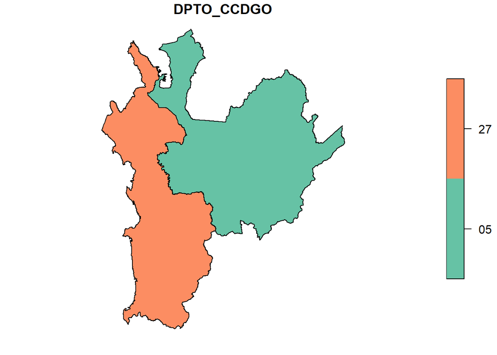

```r
plot(GROUP_1[1])
```

```r
#Group 2
Qs = quantile(DEPARTMENTS_1$DPTO_NAREA) #To obtain the quartiles.
Qs
```

```
##           0%          25%          50%          75%         100%
##     49.42425  20619.00959  24139.40123  48353.21903 109497.05379
```

```r
Qs[2]
```

```
##      25%
## 20619.01
```

```r
GROUP_2 = subset(DEPARTMENTS_1, DPTO_NAREA <= Qs[2] & DPTO_ANO_C >= 1950)
GROUP_2
```

```
## Simple feature collection with 5 features and 10 fields
## Geometry type: MULTIPOLYGON
## Dimension:     XY
## Bounding box:  xmin: -81.73562 ymin: 4.075311 xmax: -71.11296 ymax: 13.39473
## Geodetic CRS:  WGS 84
##    DPTO_CCDGO                                               DPTO_CNMBR
## 4          70                                                    SUCRE
## 9          44                                               LA GUAJIRA
## 18         63                                                  QUINDIO
## 19         66                                                RISARALDA
## 31         88 ARCHIPIÉLAGO DE SAN ANDRÉS, PROVIDENCIA Y SANTA CATALINA
##    DPTO_ANO_C                                     DPTO_ACT_A  DPTO_NAREA
## 4        1966                 Ley 47 del 8 de Agosto de 1966 10591.84594
## 9        1964 Acto Legislativo No. 1 de Diciembre 28 de 1964 20619.00959
## 18       1966                               Ley 2 TM de 1966  1933.57085
## 19       1966              Ley 70 del 1 de Diciembre de 1966  3556.77445
## 31       1991     Artículo 310 Constitucion Politica de 1991    49.42425
##    DPTO_CSMBL DPTO_VGNC  SHAPE_AREA  SHAPE_LEN AREA
## 4           3      2020 0.870810349  8.5708693   NA
## 9           3      2020 1.706874490 10.7869049   NA
## 18          3      2020 0.157423729  2.5548254   NA
## 19          3      2020 0.289790632  4.8436149   NA
## 31          3      2020 0.004049898  0.6852594   NA
##                          geometry
## 4  MULTIPOLYGON (((-75.5232 10...
## 9  MULTIPOLYGON (((-71.65195 1...
## 18 MULTIPOLYGON (((-75.70194 4...
## 19 MULTIPOLYGON (((-76.00824 5...
## 31 MULTIPOLYGON (((-81.7042 12...
```

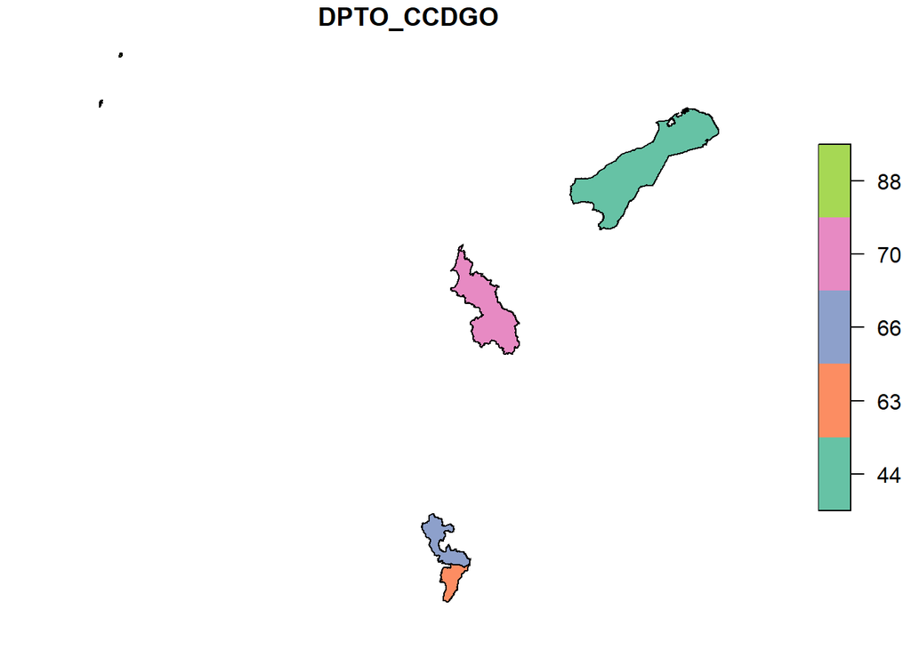

```r
plot(GROUP_2[1])
```

### **Crop(clip)**

```r
AMAZONIA = read_sf(dsn = ".", layer = "Lim_Amazonia")

DEP_AMAZONIA = st_crop(x = DEPARTMENTS_1, y = AMAZONIA)
DEP_AMAZONIA
```

```
## Simple feature collection with 21 features and 10 fields
## Geometry type: GEOMETRY
## Dimension:     XY
## Bounding box:  xmin: -77.67062 ymin: -4.229406 xmax: -66.84722 ymax: 4.969782
## Geodetic CRS:  WGS 84
## First 10 features:
##    DPTO_CCDGO      DPTO_CNMBR DPTO_ANO_C                            DPTO_ACT_A
## 3          27           CHOCÓ       1947     Ley 13 del 3 de Noviembre de 1947
## 10         19           CAUCA       1857                   15 de junio de 1857
## 11         76 VALLE DEL CAUCA       1910 Decreto No 340 de 16 de Abril de 1910
## 12         41           HUILA       1905                        Ley 46 de 1905
## 13         18         CAQUETÁ       1981    Ley 78 del 29 de Diciembre de 1981
## 14         50            META       1959   Ley 118 del 16 de Diciembre de 1959
## 15         15          BOYACÁ       1886         Constitucion Politica de 1886
## 16         25    CUNDINAMARCA       1886         Constitucion Politica de 1886
```

[output cut: 24 more lines]

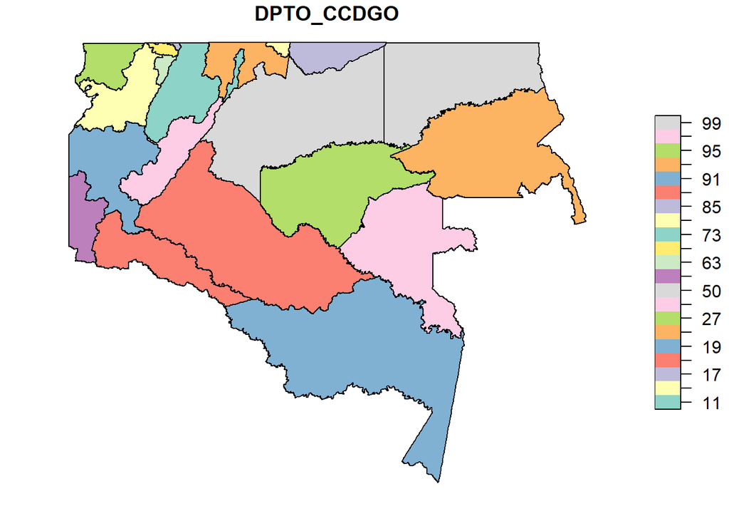

```r
plot(DEP_AMAZONIA[1])
```

### **Aggregate (dissolve)**

You can aggregate polygons of a spatial feature vector object, according to the IDs vector specifying which input polygons belong to which output polygons; internal boundaries are dissolved. This tutorial present one options for aggregating polygons using the function st_union() of the library sf. We need to read the municipalities of Colombia (MUNI) at this point of the tutorial and subset the municipalities of the department of Cauca.

```r
MUNI =  st_read(dsn = ".", layer = "MGN_MPIO_POLITICO")
table(MUNI$DPTO_CNMBR)
```

```
##
##                                                 AMAZONAS
##                                                       11
##                                                ANTIOQUIA
##                                                      125
##                                                   ARAUCA
##                                                        7
## ARCHIPIÉLAGO DE SAN ANDRÉS, PROVIDENCIA Y SANTA CATALINA
##                                                        2
##                                                ATLÁNTICO
##                                                       23
##                                             BOGOTÁ, D.C.
##                                                        1
##                                                  BOLÍVAR
##                                                       46
##                                                   BOYACÁ
##                                                      123
##                                                   CALDAS
##                                                       27
##                                                  CAQUETÁ
##                                                       16
##                                                 CASANARE
##                                                       19
##                                                    CAUCA
##                                                       42
##                                                    CESAR
##                                                       25
##                                                    CHOCÓ
##                                                       30
##                                                  CÓRDOBA
##                                                       30
##                                             CUNDINAMARCA
##                                                      116
##                                                  GUAINÍA
##                                                        8
##                                                 GUAVIARE
##                                                        4
##                                                    HUILA
##                                                       37
##                                               LA GUAJIRA
```

[output cut: 12 more lines]

```
##                                                       12
##                                                RISARALDA
##                                                       14
##                                                SANTANDER
##                                                       87
##                                                    SUCRE
##                                                       26
##                                                   TOLIMA
##                                                       47
##                                          VALLE DEL CAUCA
##                                                       42
##                                                   VAUPÉS
##                                                        6
##                                                  VICHADA
##                                                        4
```

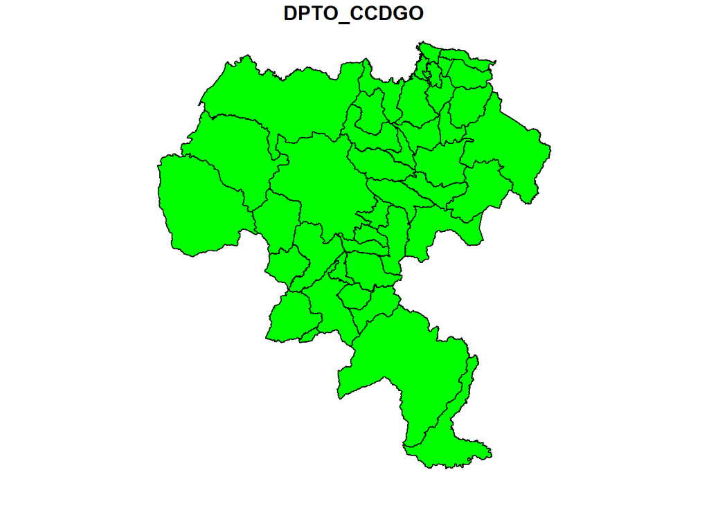

```r
CAUCA_MUNI = MUNI[MUNI$DPTO_CNMBR == "CAUCA",]
plot(CAUCA_MUNI[1],col = "green")
```

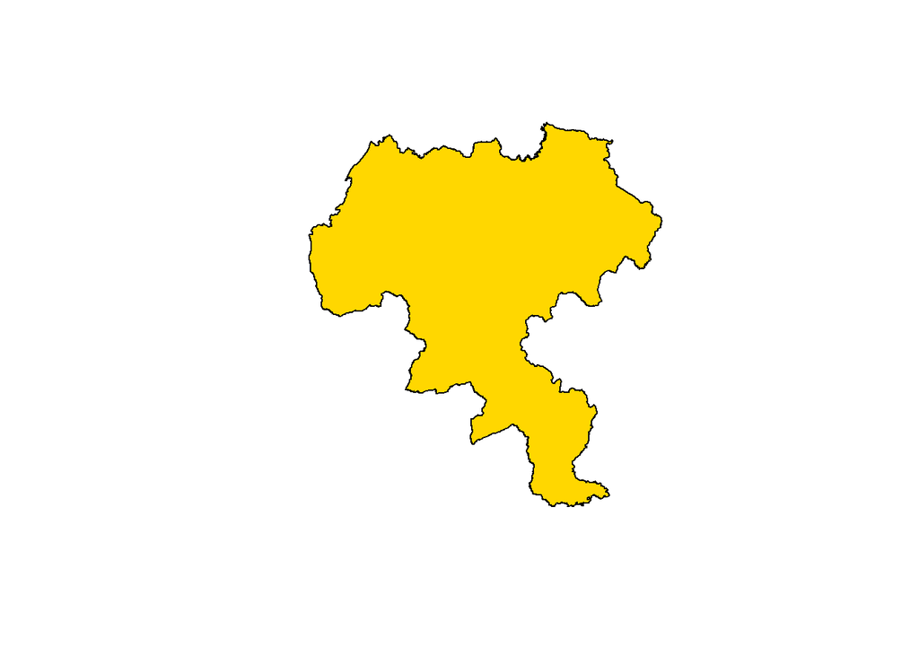

```r
CAUCA_MUNI_dis_2 = st_union(CAUCA_MUNI)
plot(CAUCA_MUNI_dis_2[1], col = "gold")
```

### **Centroids**

The function st_centroid() calculates the centroid of the given geometry. Let’s go to calculate them for CAUCA_MUNI.

```r
st_crs(CAUCA_MUNI)
```

```
## Coordinate Reference System:
##   User input: WGS 84
##   wkt:
## GEOGCRS["WGS 84",
##     DATUM["World Geodetic System 1984",
##         ELLIPSOID["WGS 84",6378137,298.257223563,
##             LENGTHUNIT["metre",1]]],
##     PRIMEM["Greenwich",0,
##         ANGLEUNIT["degree",0.0174532925199433]],
##     CS[ellipsoidal,2],
##         AXIS["latitude",north,
##             ORDER[1],
##             ANGLEUNIT["degree",0.0174532925199433]],
##         AXIS["longitude",east,
##             ORDER[2],
##             ANGLEUNIT["degree",0.0174532925199433]],
##     ID["EPSG",4326]]
```

```r
CENT = st_centroid(CAUCA_MUNI, byid=TRUE)
```

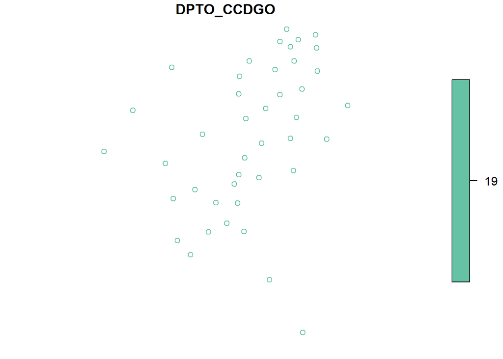

```r
plot(CENT[1])
```

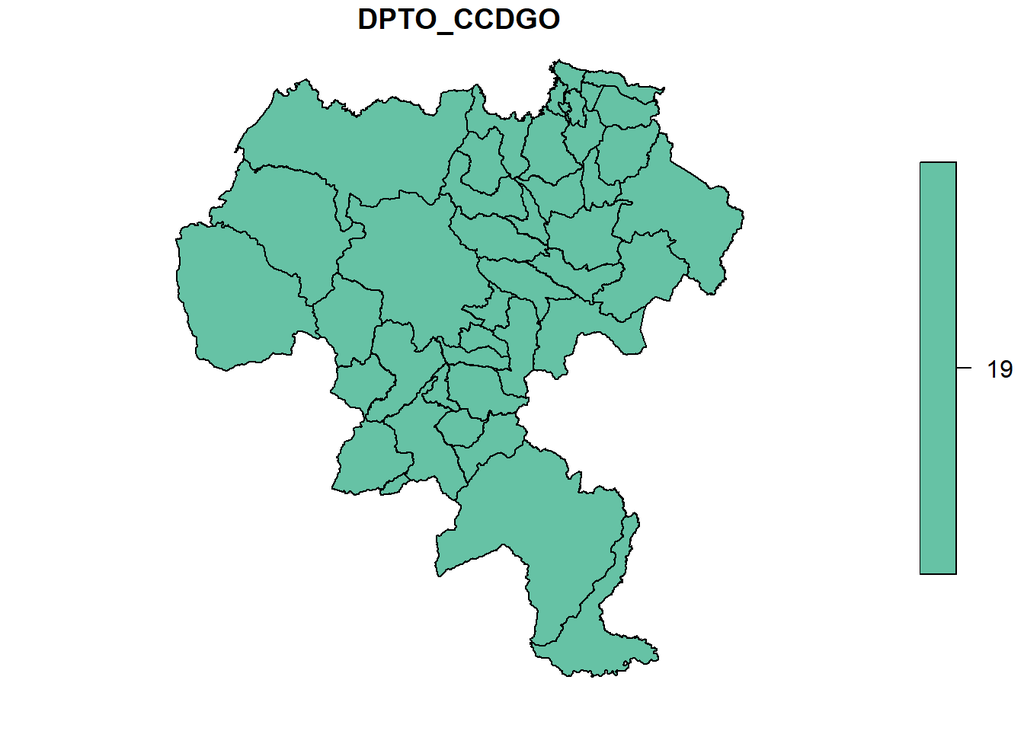

```r
#
plot(CAUCA_MUNI[1])
plot(CENT[1], add=T, col = "red")
```

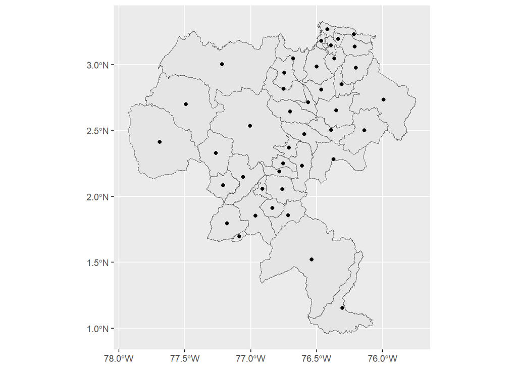

```r
#

library(ggplot2)
ggplot(data = CAUCA_MUNI) +
    geom_sf() +
    geom_sf(data = CENT)
```

Now, we can estimate the distances among the centroids. The [m] means meters, but if you need another unit, you can change the argument “which”. The operator “%>%” of the dplyr package is used to concatenate operations:

third(second(first(x))) first(x) %>% second(x) %>% third(x)

```r
distances <- CENT %>%
    st_cast("POINT") %>%
    st_distance(st_centroid(CENT))

dim(distances)
```

```
## [1] 42 42
```

```r
distances_2 = as.data.frame(distances)

distances[1:4, 1:4]
```

```
## Units: [m]
##           [,1]      [,2]         [,3]         [,4]
## [1,]      0.00  20169.83 1.702051e+05 1.141555e+04
## [2,]  20169.83      0.00 1.876849e+05 2.023701e+04
## [3,] 170205.11 187684.93 2.210388e-11 1.788096e+05
## [4,]  11415.55  20237.01 1.788096e+05 4.420776e-11
```

### **Projections**

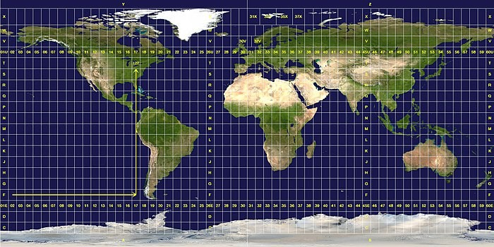

**Figure 1**. UTM zones.

```r
CAUCA_MUNI_UTM18 = st_transform(CAUCA_MUNI, crs = 32618)
st_crs(CAUCA_MUNI_UTM18)
```

```
## Coordinate Reference System:
##   User input: EPSG:32618
##   wkt:
## PROJCRS["WGS 84 / UTM zone 18N",
##     BASEGEOGCRS["WGS 84",
##         ENSEMBLE["World Geodetic System 1984 ensemble",
##             MEMBER["World Geodetic System 1984 (Transit)"],
##             MEMBER["World Geodetic System 1984 (G730)"],
##             MEMBER["World Geodetic System 1984 (G873)"],
##             MEMBER["World Geodetic System 1984 (G1150)"],
##             MEMBER["World Geodetic System 1984 (G1674)"],
##             MEMBER["World Geodetic System 1984 (G1762)"],
##             MEMBER["World Geodetic System 1984 (G2139)"],
##             ELLIPSOID["WGS 84",6378137,298.257223563,
##                 LENGTHUNIT["metre",1]],
##             ENSEMBLEACCURACY[2.0]],
##         PRIMEM["Greenwich",0,
##             ANGLEUNIT["degree",0.0174532925199433]],
##         ID["EPSG",4326]],
##     CONVERSION["UTM zone 18N",
##         METHOD["Transverse Mercator",
##             ID["EPSG",9807]],
##         PARAMETER["Latitude of natural origin",0,
##             ANGLEUNIT["degree",0.0174532925199433],
##             ID["EPSG",8801]],
##         PARAMETER["Longitude of natural origin",-75,
##             ANGLEUNIT["degree",0.0174532925199433],
##             ID["EPSG",8802]],
##         PARAMETER["Scale factor at natural origin",0.9996,
##             SCALEUNIT["unity",1],
##             ID["EPSG",8805]],
##         PARAMETER["False easting",500000,
##             LENGTHUNIT["metre",1],
##             ID["EPSG",8806]],
##         PARAMETER["False northing",0,
##             LENGTHUNIT["metre",1],
##             ID["EPSG",8807]]],
##     CS[Cartesian,2],
##         AXIS["(E)",east,
##             ORDER[1],
##             LENGTHUNIT["metre",1]],
##         AXIS["(N)",north,
##             ORDER[2],
##             LENGTHUNIT["metre",1]],
##     USAGE[
##         SCOPE["Navigation and medium accuracy spatial referencing."],
##         AREA["Between 78°W and 72°W, northern hemisphere between equator and 84°N, onshore and offshore. Bahamas. Canada - Nunavut; Ontario; Quebec. Colombia. Cuba. Ecuador. Greenland. Haiti. Jamaica. Panama. Turks and Caicos Islands. United States (USA). Venezuela."],
##         BBOX[0,-78,84,-72]],
##     ID["EPSG",32618]]
```

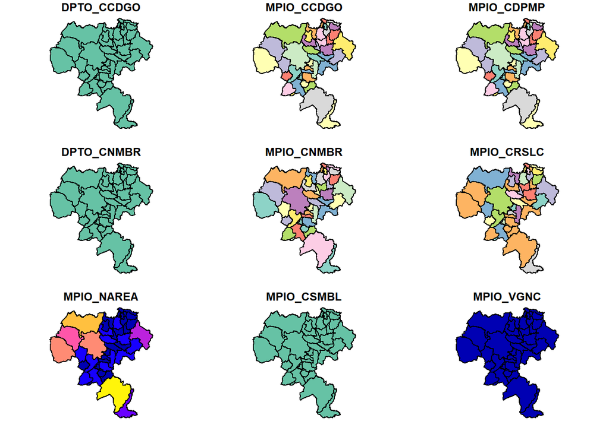

```r
plot(CAUCA_MUNI_UTM18)
```

### **Buffers**

Buffer is a technique commonly used to determine areas that are proximal to certain objects. Traditionally, buffers are circular.

```r
st_crs(CENT)
```

```
## Coordinate Reference System:
##   User input: WGS 84
##   wkt:
## GEOGCRS["WGS 84",
##     DATUM["World Geodetic System 1984",
##         ELLIPSOID["WGS 84",6378137,298.257223563,
##             LENGTHUNIT["metre",1]]],
##     PRIMEM["Greenwich",0,
##         ANGLEUNIT["degree",0.0174532925199433]],
##     CS[ellipsoidal,2],
##         AXIS["latitude",north,
##             ORDER[1],
##             ANGLEUNIT["degree",0.0174532925199433]],
##         AXIS["longitude",east,
##             ORDER[2],
##             ANGLEUNIT["degree",0.0174532925199433]],
##     ID["EPSG",4326]]
```

```r
buffers_1 <-st_buffer(CENT,dist = 2000)#it should be convertible to arc_degree if x has geographic coordinates

CENT_UTM18 = st_transform(CENT, 32618)
st_crs(CENT_UTM18)
```

```
## Coordinate Reference System:
##   User input: EPSG:32618
##   wkt:
## PROJCRS["WGS 84 / UTM zone 18N",
##     BASEGEOGCRS["WGS 84",
##         ENSEMBLE["World Geodetic System 1984 ensemble",
##             MEMBER["World Geodetic System 1984 (Transit)"],
##             MEMBER["World Geodetic System 1984 (G730)"],
##             MEMBER["World Geodetic System 1984 (G873)"],
##             MEMBER["World Geodetic System 1984 (G1150)"],
##             MEMBER["World Geodetic System 1984 (G1674)"],
##             MEMBER["World Geodetic System 1984 (G1762)"],
##             MEMBER["World Geodetic System 1984 (G2139)"],
##             ELLIPSOID["WGS 84",6378137,298.257223563,
##                 LENGTHUNIT["metre",1]],
##             ENSEMBLEACCURACY[2.0]],
##         PRIMEM["Greenwich",0,
##             ANGLEUNIT["degree",0.0174532925199433]],
##         ID["EPSG",4326]],
##     CONVERSION["UTM zone 18N",
##         METHOD["Transverse Mercator",
##             ID["EPSG",9807]],
##         PARAMETER["Latitude of natural origin",0,
##             ANGLEUNIT["degree",0.0174532925199433],
##             ID["EPSG",8801]],
##         PARAMETER["Longitude of natural origin",-75,
##             ANGLEUNIT["degree",0.0174532925199433],
##             ID["EPSG",8802]],
##         PARAMETER["Scale factor at natural origin",0.9996,
##             SCALEUNIT["unity",1],
##             ID["EPSG",8805]],
##         PARAMETER["False easting",500000,
##             LENGTHUNIT["metre",1],
##             ID["EPSG",8806]],
##         PARAMETER["False northing",0,
##             LENGTHUNIT["metre",1],
##             ID["EPSG",8807]]],
##     CS[Cartesian,2],
##         AXIS["(E)",east,
##             ORDER[1],
##             LENGTHUNIT["metre",1]],
##         AXIS["(N)",north,
##             ORDER[2],
##             LENGTHUNIT["metre",1]],
##     USAGE[
##         SCOPE["Navigation and medium accuracy spatial referencing."],
##         AREA["Between 78°W and 72°W, northern hemisphere between equator and 84°N, onshore and offshore. Bahamas. Canada - Nunavut; Ontario; Quebec. Colombia. Cuba. Ecuador. Greenland. Haiti. Jamaica. Panama. Turks and Caicos Islands. United States (USA). Venezuela."],
##         BBOX[0,-78,84,-72]],
##     ID["EPSG",32618]]
```

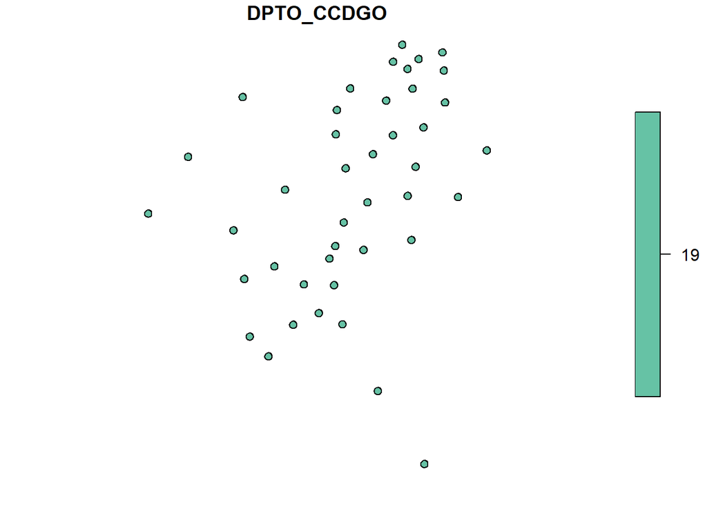

```r
buffers_2 = st_buffer(CENT_UTM18,dist = 2000)
plot(buffers_2[1])
```

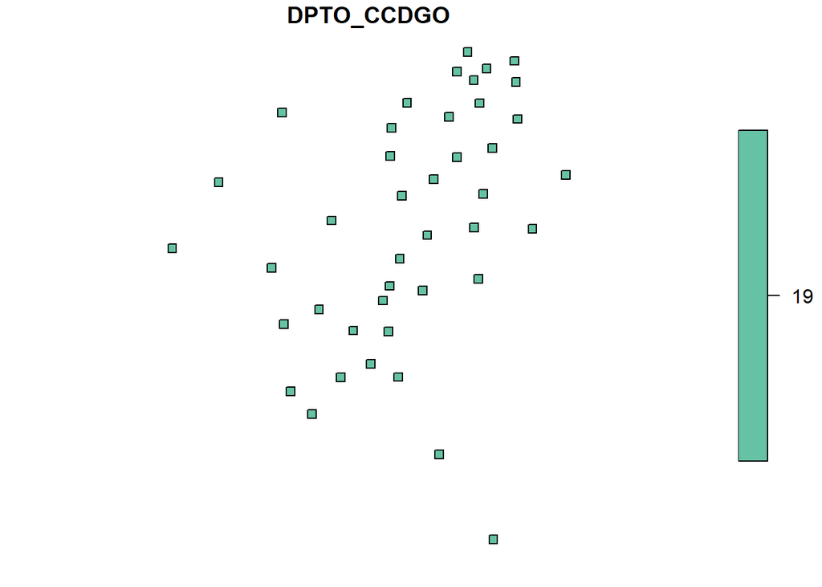

```r
buffers_2 <-st_buffer(CENT_UTM18,dist = 2000, endCapStyle = "SQUARE")
plot(buffers_2[1])
```

### **VI. Assignment**

Create a script (code) that solves and shows the next questions (each question gives 2.5 points to your grade assignment):

1. Read the file MGN_DPTO_POLITICO.shp in R using the function of the sf package to read .shp files. Name this object ORG_LEVEL_2. What is the class of this object? Show the first six rows of ORG_LEVEL_2. Plot ORG_LEVEL_2.
2. Show the Geographic Coordinate Systems of ORG_LEVEL_2. Built a vector called nombres with the names of ORG_LEVEL_2.
3. Create a vector with the foundation date of the departments (variable DPTO_ANO_C), called FUNDACION. What are the foundation years of the youngest and oldest departments? I recommend the use of the functions max() and min() to know these two years. Create a “sf-data.frame” object with the youngest departments of Colombia (using ORG_LEVEL_2) and called JOVENSITOS. Also, you must plot JOVENSITOS. In this new object, JOVENSITOS, subset the largest and smallest departments and plot them (the variable or column SHAPE_AREA is the area of the departments).
4. Project ORG_LEVEL_2 to Transversal Mercator, called ORG_LEVEL_2_MER this new “sf-data.frame”. Now create the centroids for the departments of ORG_LEVEL_2_MER (plot these centroids) and the data.frame of their distances. Which one are the mean, median, standard deviation of the distances?